# Assignment 2

**Due Sunday, May 9th, 23:59**

## General notice about submissions

In every problem we ask you to create one or more functions with specific names. Suppose you are asked to create functions named `foo()` and `bar()`. When you submit your code, the code must have ONLY the definitions of the functions, and not any CALLS to them. Also, you must not include any `set.seed()` statements in your submissions.

Good example:

```
# mysubmission.r
foo <- function(x){
    return 2*x
}
bar <- function(x, y){
    return x+y
}
baz <- function(N){
    runif(N)*2
}
```

Bad example:

```
# mysubmission.r
foo <- function(x){
    return 2*x
}
foo(c(1,2,3)) # don't call the function here
bar <- function(x, y){
    return x+y
}
mysum <- bar(3,2) # no assignment, no function call.

set.seed(111) # don't set the random seed here
baz <- function(N){
    runif(N)*2
}
```

The reason is that when we run your code for testing purposes, such calls may create some unwanted side effects and interfere with the grading.

When you work on your programs, feel free to call your functions to check that they give correct results. However, in the final submission keep only the function definitions. Your submission should not do anything except for defining the functions.

Keep in mind that we are going to test your programs with new data that has the same structure but different content. Write your programs to be as general as possible within the description.

I suggest that you come up with further test cases on your own, and check that they give the expected output. Make your final tests after restarting R, so that existing variables do not confound your program.

You must work on the assignment by yourself. **Giving or receiving any help will not be tolerated.**

# Problem 1

*(10 points)*

Write a function `distance(u, v)` that takes two points `u` and `v` as vectors and returns the Euclidian distance between them.

The distance can be calculated using the Pythagorean thorem $$d = \sqrt{(u_1 - v_1)^2 + (u_2-v_2)^2 +\cdots + (u_n-v_n)^2}$$ where $u_i$ and $v_i$ are the i-th element of the vectors $u$ and $v$, respectively, and $n$ is the number of elements in each vector.

**Note**

- If the length of the input vectors do not match, the function should print an error message and return `NULL`.
- The function should work with vectors of arbitrary length, provided they have the same length.

**Examples**

```
> distance(c(3,0), c(0,4))
[1] 5
> distance(c(1,2,5-1,2), c(0,4,1-2,3))
[1] 5.567764
> distance(c(1,2), c(1,2,3))
[1] "vectors must have the same length"
NULL
```

## Problem 2

*(25 points)*

You are given an n-by-2 matrix `m` which stores the Cartesian coordinates of n points in the plane. You are also given a two-element vector `x` with the coordinates of a new point.

Using the Pythagorean formula for the distance, we can calculate the distance between `x` and every row of `m`. One of the rows in `m` will be the nearest neighbor of `x`, another one will be the second nearest, etc.

For example, in the figure below, the point nearest to $x=(0,2)$ is $(1,2)$, second nearest neighbor is $(1,1)$, third nearest is $(2,0)$, and the fourth nearest (farthest) is $(3,3)$.

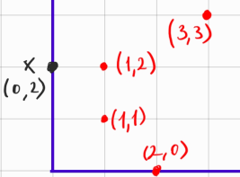

Our goal is to find the k-nearest point on `m` to `x`, for a given k between 1 and n.

Write a function named `get_neighbor(x, m, k)` that takes a vector `x` and matrix `m` as described, and returns the row in `m` that is the k-nearest neighbor of `x` (see example).

**Example**

```
> x <- c(0,2)
> m <- rbind( c(1,1), c(1,2), c(3,3), c(2,0) )
> get_neighbor(x, m, 1)
[1] 1 2
> get_neighbor(x, m, 4)
[1] 3 3
> get_neighbor(x, m, 5)
[1] "k is larger than the rows of m."
NULL
```

**Example**

```
> RNGversion("3.3.1")
> set.seed(12345)
> m <- matrix( runif(100), ncol=2) # A random matrix with 50 rows
> x <- c(0.5, 0.5)
> get_neighbor(x, m, 20) # get the 20th nearest point to x.
[1] 0.1789636 0.6003570
```

**Hint**

Collect the distances between `x` and every row of `m` in a vector, then use the `order()` function to get the indices of the sorted vector. Use this to get the relevant row of `m`.

## Problem 3

*(35 points)*

Write a function named `number_to_text(x)` that takes an integer `x` between 0 and 999 and returns its pronunciation as a string.

**Examples**

```
> for (x in c(0,5,10,15,57,100,105,213,538,999))
    print(number_to_text(x))
[1] "zero"
[1] "five"
[1] "ten"
[1] "fifteen"
[1] "fifty-seven"
[1] "one hundred"
[1] "one hundred and five"
[1] "two hundred and thirteen"
[1] "five hundred and thirty-eight"
[1] "nine hundred and ninety-nine"
```

Depending on your method, you might get extra spaces in the strings. This is acceptable.

**Hints**

Use the `paste()` or `paste0()` functions that combine several strings into one string (see `help(paste)`).

Inside your function, you might define three character vectors

- `ones <- c("one","two", ..., "ten")`
- `teens <- c("eleven","twelve",..."nineteen")`
- `tens <- c("ten","twenty", ..."ninety")`

Extract the digits of the input number and combine the relevant words from the vectors. You will need to use if-statements to accomodate special cases.

Start by figuring out how to handle two-digit numbers. Then include the third digit (hundreds).

**Note**: Hardcoded solutions that do not involve any computational logic will **not** be accepted (such as `if(x==0) return("zero")...if(x==999) return("nine hundred and ninety nine")`).

## Problem 4

**(A)** *(20 points)* Write a function named `powerseries(x,n)` that takes a real number (or a vector of numbers) `x` and a nonnegative integer `n`, and returns the value of the sum $$ 1 + x + \frac{x^2}{2!} + \frac{x^3}{3!} + \cdots + \frac{x^n}{n!} = \sum_{i=0}^{n} \frac{x^i}{i!}$$

If the parameter `x` is a vector, the function's output should be a vector.

If the parameter `n` is negative, the function should display an error message "`parameter n should not be negative`" and return `NULL` (`NULL` is a built-in constant in R).

**Hint:** For given $x$, you can evaluate the sum in a loop. Think about how you can obtain the next term in the sum using the previous term.

**Examples**:

```
> powerseries(x=1, n=0)
[1] 1
> powerseries(x=1, n=7)
[1] 2.718254
> powerseries(x=c(-1,0,1), n=7)
[1] 0.3678571 1.0000000 2.7182540
> powerseries(x=2, n=-1)
[1] parameter n should not be negative
NULL
```

**(B)** *(10 points)* Write a function named `plot_series(z,n)` that takes a vector of real numbers `z` and a nonnegative integer `n`, and produces a line plot of `powerseries(z,n)` values, together with the function `exp(z)`. The plot title and axis labels should be set as shown. The `exp(z)` curve should be in red.

**Examples**

```
> plot_series(seq(-5,5,length.out = 101), n=3)
```

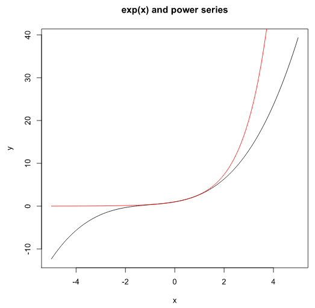

```
> plot_series(seq(-5,5,length.out = 101), n=7)
```

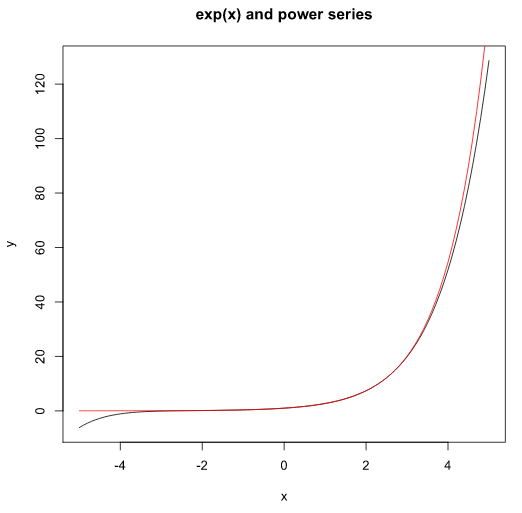

## Submission template

The function definitions should be submitted as a single source file named *assignment2.R*, with the following contents:

```
distance <- function(u,v) {
    # your code here
    }

get_neighbor <- function(x, m, k) {
    # your code here
    }

number_to_text <- function(x) {
    # your code here
    }

powerseries <- function(x, n){
    # your code here
    }

plot_series <- function(z, n){
    # your code here
    }
```

You don't need to submit the plot images generated by your functions.